# MBC Experiment

LD

7/15/2020

# Step 1: Prepare Data

The goal is to select statistically similar zip codes in LA county and at least one other county.

## Prepare data

Load standardized data with response rates (already QA’d for MBC reports), load the Black HTC index and call HTC-related ACS data via api.

```r
# load standardized, summarzied data and pull out zip code estimates
stand_data <- fread(paste0(wcl_root, "My Black Counts/standardized_data.csv"), stringsAsFactors = FALSE, data.table = FALSE,
                  colClasses = c("GEOID"="character", "zip"="character"))

# query only zip code summaries
stand_data <-
  stand_data %>%
  filter(level =="zip code" & county_name %in% c("Los Angeles", "Alameda")) %>%
  select(-c(gq_pop_pct, diff, REGION, Turf_final, BLKHTC_num, BLKHTCCA, housecur, resp10, resp20_10_diff, blackhh_prc_cv)) %>%
  mutate(blackhh_prc = blackhh/tothh)


### Load Black HTC Data ###
# these are all rates at the tract level, instead of raw numbers that I can summarize, unfortunately. Maybe I can average tract rates in the zip ?
htc <- read.dbf(paste0(wcl_root, "My Black Counts/BlackHTC/BLKHTC_final/BLKHTC_final.dbf"), as.is = TRUE)
htc <- htc[,c(5, 24:39, 41)]

# convert all character cols to numeric
htc_dat <-
htc %>%
  mutate_at(c('popchng', 'newres', 'vacunits', 'multunit',
                    'nobrdbnd', 'renter', 'yngadlt', 'fborn', 'blwpov', 'unemp', 'male', 'child', 'comphh', 'noncit', 'arrests',
                    'voters', 'BLKHTC_num'),as.numeric)
```

Prepare ACS data

```r
# get some new stats
# internet B25003B
# poverty B17001B
# multiunit B25032B
# immigrants B05003B

# variables for foreign born
immigvars <- subset(v18, name %like% "B05003B" & label %like% "Foreign born" & !label %like% "Foreign born!!" )
immigvars <- immigvars$name

# vars for multiunit housing
multiunvars <- subset(v18, name %like% "B25032B" & !label %like% "!!2" & !label %like% "!!1" & !name %like% "_001" )
multiunvars <- multiunvars$name

internetvars <- subset(v18, name %like% "B28009B" & name %in% c("B28009B_005", "B28009B_006"))
internetvars <- internetvars$name

blackvars <-
list(
# get tract data
    immig = get_acs(geography = "tract", state="CA", county = c("037", "001"), variables = immigvars, summary_var = "B05003B_001",
                    survey = "acs5", year=2018) %>%
      mutate(level = "tract",
             var = "foreign born"),

    internet = get_acs(geography = "tract", state="CA", county = c("037", "001"), variables = internetvars, summary_var = "B28009B_001",
                    survey = "acs5", year=2018) %>%
      mutate(level = "tract",
             var = "internet"),

    rent = get_acs(geography = "tract", state="CA", county = c("037", "001"), variables = "B25003B_003", summary_var = "B25003B_001",
                    survey = "acs5", year=2018) %>%
      mutate(level = "tract",
             var = "renter"),

    pov = get_acs(geography = "tract", state="CA", county = c("037", "001"), variables = "B17001B_002", summary_var = "B17001B_001",
                    survey = "acs5", year=2018) %>%
      mutate(level = "tract",
             var = "poverty"),

    multiun = get_acs(geography = "tract", state="CA", county = c("037", "001"), variables = multiunvars, summary_var = "B25032B_001",
                    survey = "acs5", year=2018) %>%
      mutate(level = "tract",
             var = "multiunit"))


# summarize vars that need it (ie foreign born)
blackvars <- lapply(blackvars, function(x) x %>%
                      group_by(GEOID, level, var) %>%
                      summarize(est = sum(estimate, na.rm=T),
                                est_moe = moe_sum(moe, estimate, na.rm = T),
                                tot = mean(summary_est, na.rm=T),
                                tot_moe = mean(summary_moe, na.rm=T)))
```

Zip-tract crosswalk

- This crosswalk has been QA’d for previous versions of MBC reports
- Zip data source: ESRI 2018 (W:/Base/esri/2018/esri_zip_code_poly_ca.shp)
- First, intersect zip codes and counties–a zip has to have at least 10% of its area in the county for it to be assigned to that county.
- Second, intersect zips and tract. Where the most of a tract’s area is (i.e. which zip code) is the tract-zip assignment. This is to avoid duplicating tracts, and creates a continuous, non-overlapping representative zip code layer. I didn’t do any proportional allocation of tract demographics because that seems like adding extra assumptions and error on top of already-problematic zip codes.

```r
# export tract-city-zip-county crosswalk
tract_final_df <-  fread(paste0(wcl_root, "My Black Counts/geometry_id_tract_crosswalk.csv"),
                         stringsAsFactors = FALSE, data.table = FALSE,
                         colClasses = c("COUNTYFP"="character", "GEOID"="character", "ZIP_CODE"="character"))

head(tract_final_df)
```

```
##   COUNTYFP       GEOID tract_name area_tract ZIP_CODE PLACE      NAME
## 1      009 06009000300       3.00  457372845    95246    NA      <NA>
## 2      011 06011000300       3.00  953001154    95987    NA      <NA>
## 3      013 06013303102    3031.02    6502907    94513  8142 Brentwood
## 4      013 06013303202    3032.02    3703304    94513  8142 Brentwood
## 5      013 06013303203    3032.03    6382639    94513  8142 Brentwood
## 6      013 06013307102    3071.02    1616945    94509  2252   Antioch
##   COUNTY  county_name
## 1      9    Calaveras
## 2     11       Colusa
## 3     13 Contra Costa
## 4     13 Contra Costa
## 5     13 Contra Costa
## 6     13 Contra Costa
```

Join the Black HTC data to the zip code crosswalk

```r
# only do this for LA County and Alameda county--going to focus in on oakland and la
htc_zip_mean <-
tract_final_df %>%
  select(GEOID, COUNTYFP, ZIP_CODE, county_name, NAME) %>%
  full_join(htc_dat, by="GEOID") %>%
  filter(COUNTYFP %in% c('037', '001')) %>%

  # group by zip and get summaries of the Black HTC characteristics
  group_by(ZIP_CODE) %>%
  summarise_at(vars(popchng, newres, vacunits, multunit,
                    nobrdbnd, renter, yngadlt, fborn, blwpov, unemp, male, child, comphh, noncit, arrests,
                    voters, BLKHTC_num), mean, na.rm=T)

head(htc_zip_mean)
```

```
## # A tibble: 6 x 18
##   ZIP_CODE popchng newres vacunits multunit nobrdbnd renter yngadlt  fborn
##   <chr>      <dbl>  <dbl>    <dbl>    <dbl>    <dbl>  <dbl>   <dbl>  <dbl>
## 1 90001      -5.96  20.3      4.59     18.4     29.4   47.7    8.65  2.72
## 2 90002      -9.59   7.46     3.42     36.9     51.5   71.0   12.1   0.791
## 3 90003       9.59  12.9      6.06     39.6     46.4   80.9   11.3   3.75
## 4 90004      76.0   15.4      9.18     72.6     21.8   73.7    9.51  8.5
## 5 90005      16.1   21.6      5.96     80.0     21.2   79.1    6.38 12.4
## 6 90006     -20.0   13.6      5.64     75.0     28.0   78.1    9.23 21.0
## # ... with 9 more variables: blwpov <dbl>, unemp <dbl>, male <dbl>,
## #   child <dbl>, comphh <dbl>, noncit <dbl>, arrests <dbl>, voters <dbl>,
## #   BLKHTC_num <dbl>
```

```r
# test for duplicates
# summary(htc_zip_mean %>%
#   group_by(ZIP_CODE) %>%
#   summarize(dup = n()))
# summarize
```

Join the ACS var list to the tract-zip crosswalk

```r
# collapse list
blackvars_df <- do.call("rbind", blackvars)

black_zip_summary <-
# join crosswalk
blackvars_df %>%
  left_join(tract_final_df, by="GEOID") %>%

  #summarize by zip code
  group_by(ZIP_CODE, var) %>%
  summarize(est = sum(est, na.rm=T),
            est_moe = moe_sum(est_moe, est, na.rm = T),
            tot = sum(tot, na.rm=T),
            tot_moe = moe_sum(tot_moe, tot, na.rm = T),
            prc = est/tot,
            prc_moe = moe_prop(est, tot, est_moe, tot_moe),
            prc_cv = (prc_moe/1.645)/prc) %>%

  # keep only percentage for zip
  select(ZIP_CODE, var, prc) %>%

  pivot_wider(names_from = var, values_from = prc) %>%
  filter(!is.na(ZIP_CODE)) %>%
  as.data.frame()

head(black_zip_summary)
```

```
##   ZIP_CODE foreign born  internet multiunit   poverty    renter
## 1    90001  0.036923077 0.3125867 0.1948843 0.3692473 0.6061713
## 2    90002  0.007481297 0.4709977 0.3139617 0.3908526 0.6704465
## 3    90003  0.049662402 0.3219148 0.2663199 0.4363555 0.8101430
## 4    90004  0.058848256 0.2039413 0.3186312 0.2463096 0.9414449
## 5    90005  0.204259439 0.3123746 0.3968164 0.2546706 0.9704377
## 6    90006  0.162995595 0.2018156 0.3527738 0.3463061 0.9416785
```

```r
# check for duplicate zip codes
summary(
  black_zip_summary %>%
  group_by(ZIP_CODE) %>%
  summarize(dup = n()))
```

```
##    ZIP_CODE              dup
##  Length:331         Min.   :1
##  Class :character   1st Qu.:1
##  Mode  :character   Median :1
##                     Mean   :1
##                     3rd Qu.:1
##                     Max.   :1
```

#### Join the summary variables to the standardized data with response rates

```r
# join Black summary vars to the standardized data
dat <-
stand_data %>%
  select(zip, county_name, city, estimate, prc, resp20_old, resp20, blackhh, blackhh_prc, count_tract, count_htc ) %>%

  # join black variable zip summary by zip code
  full_join(black_zip_summary, by=c("zip"= "ZIP_CODE")) %>%

  # join the black htc mean by zip
  full_join(htc_zip_mean %>%
              select(ZIP_CODE, BLKHTC_num) %>%
              rename("mean_BLKHTC_num" = BLKHTC_num),
            by=c("zip"= "ZIP_CODE")) %>%

  # remove NA response records and where black hh are 0
  filter(blackhh > 0 & !is.na(resp20) & !is.na(mean_BLKHTC_num)) %>%
 # format response rate percents as decimals
   mutate(resp20_old = resp20_old/100,
         resp20 = resp20/100,
         mean_BLKHTC_num = mean_BLKHTC_num/100)   # I want to convert to decimal without losing info about the range itself



test <-
  dat %>%
  group_by(zip, county_name) %>%
  summarize(dup = n())
summary(test)
```

```
##      zip            county_name             dup
##  Length:310         Length:310         Min.   :1
##  Class :character   Class :character   1st Qu.:1
##  Mode  :character   Mode  :character   Median :1
##                                        Mean   :1
##                                        3rd Qu.:1
##                                        Max.   :1
```

# Step 2. Look for statistically similar zip codes

### Test k-means clustering

prepare data: subset by county, only keep selected numeric variables, convert zip code ids to row names.

```r
# chewck for nas
summary(dat)
```

```
##      zip            county_name            city
##  Length:310         Length:310         Length:310
##  Class :character   Class :character   Class :character
##  Mode  :character   Mode  :character   Mode  :character
##
##
##
##     estimate            prc             resp20_old         resp20
##  Min.   :   23.0   Min.   :0.002354   Min.   :0.0420   Min.   :0.0250
##  1st Qu.:  680.2   1st Qu.:0.023905   1st Qu.:0.5473   1st Qu.:0.5610
##  Median : 1429.0   Median :0.047686   Median :0.6210   Median :0.6370
##  Mean   : 3217.4   Mean   :0.088692   Mean   :0.6133   Mean   :0.6289
##  3rd Qu.: 3292.8   3rd Qu.:0.097033   3rd Qu.:0.6920   3rd Qu.:0.7085
##  Max.   :40165.0   Max.   :0.799561   Max.   :0.8530   Max.   :0.8640
##     blackhh         blackhh_prc        count_tract       count_htc
##  Min.   :   11.0   Min.   :0.001261   Min.   : 1.000   Min.   : 0.000
##  1st Qu.:  239.0   1st Qu.:0.023356   1st Qu.: 5.000   1st Qu.: 0.000
##  Median :  528.5   Median :0.049556   Median : 8.000   Median : 0.000
##  Mean   : 1268.0   Mean   :0.103608   Mean   : 8.487   Mean   : 1.294
##  3rd Qu.: 1318.5   3rd Qu.:0.113227   3rd Qu.:11.000   3rd Qu.: 1.000
##  Max.   :16119.0   Max.   :0.846784   Max.   :26.000   Max.   :15.000
##   foreign born        internet        multiunit         poverty
##  Min.   :0.00000   Min.   :0.0000   Min.   :0.0000   Min.   :0.00000
##  1st Qu.:0.05347   1st Qu.:0.0626   1st Qu.:0.2175   1st Qu.:0.08786
##  Median :0.08817   Median :0.1327   Median :0.3351   Median :0.16701
##  Mean   :0.10414   Mean   :0.1556   Mean   :0.3390   Mean   :0.18707
##  3rd Qu.:0.14024   3rd Qu.:0.2224   3rd Qu.:0.4477   3rd Qu.:0.25456
##  Max.   :0.57865   Max.   :0.7979   Max.   :1.0000   Max.   :1.00000
##      renter       mean_BLKHTC_num
##  Min.   :0.0000   Min.   :0.1036
##  1st Qu.:0.5274   1st Qu.:0.1420
##  Median :0.7071   Median :0.1625
##  Mean   :0.6659   Mean   :0.1611
##  3rd Qu.:0.8490   3rd Qu.:0.1748
##  Max.   :1.0000   Max.   :0.2390
```

```r
# los angeles county data
datk_la <-
  dat %>%
  filter(county_name =="Los Angeles" ) %>%
  select(zip, blackhh_prc, `foreign born`, internet, multiunit, poverty, renter, mean_BLKHTC_num) %>%  # prc, resp20
   column_to_rownames(var="zip")
#head(datk_la)

# alameda county data
 # just remove the duplicate zips for now, but circle back later
datk_al <-
  dat %>%
  filter(county_name =="Alameda") %>%
  mutate(flag = ifelse(city %in% c("Oakland", "San Leandro", "Hayward"), 0.5, 0)) %>%  # the three cities with the highest black hh count/prc
  select(zip, blackhh_prc, `foreign born`, internet, multiunit, poverty, renter, mean_BLKHTC_num, flag) %>% # prc, resp20
  column_to_rownames(var="zip")

# head(datk_al)
```

### Run k-mean cluster on LA zip codes

#### k = 5

- note: The total within-cluster sum of square measures the compactness (i.e goodness) of the clustering and we want it to be as small as possible.(source)[https://uc-r.github.io/kmeans_clustering]

```r
k5_la <- kmeans(datk_la, centers = 5, nstart = 25)

# total within cluster sum of squares
k5_la$tot.withinss # need to compare to other modesl
```

```
## [1] 18.08812
```

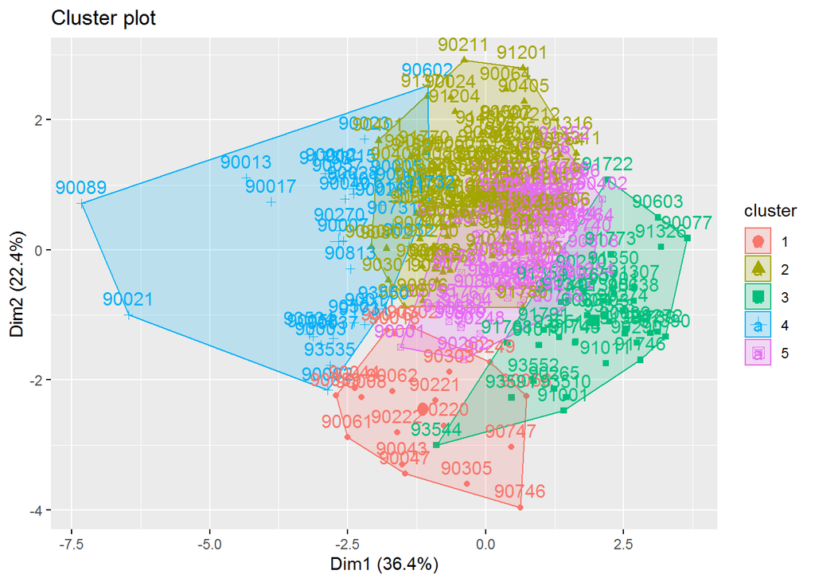

```r
### Plot LA K-means clusters (k=7)
fviz_cluster(k5_la, data = datk_la)
```

```r
# look at group  (the group I've had my eye on anywyas)
names( k5_la$cluster[ k5_la$cluster==1])
```

```
##  [1] "90008" "90016" "90018" "90043" "90044" "90047" "90056" "90059"
##  [9] "90061" "90062" "90220" "90221" "90222" "90249" "90302" "90303"
## [17] "90305" "90746" "90747"
```

```r
# [1] "90008" "90016" "90018" "90043" "90044" "90047" "90056" "90059" "90061" "90062" "90220" "90221"
# [13] "90222" "90249" "90302" "90303" "90305" "90746" "90747"

#View(subset(dat, zip %in% names(k7_la$cluster[ k7_la$cluster==1])))
```

#### k = 10

Test k=10 on LA county zip codes. k=10 is a little too large, I want larger sample sizes for statistical purposes.

```r
## try k=10
k10_la <- kmeans(datk_la, centers = 10, nstart = 25)

# total within cluster sum of squares
k10_la$tot.withinss # need to compare to other modesl
```

```
## [1] 12.54322
```

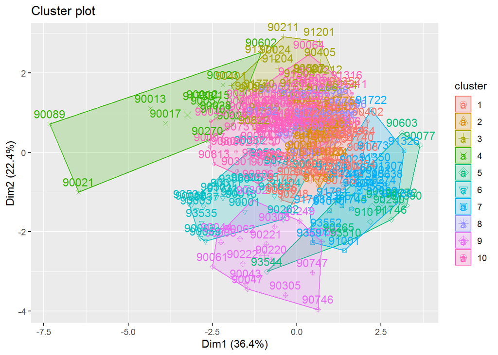

```r
# sure the 'within ss` is smaller, but that is a given with more clusters

### Plot LA K-means clusters (k=10)
fviz_cluster(k10_la, data = datk_la)
```